# Progress report 3

Sequence Processing and classification

Updated: 2019-05-09 18:57:45

## Descriptive statistics of assembled sequence

|  | SequenceLength | OverlapLength | MisMatches |
| --- | --- | --- | --- |
|  | Min. : 19.0 | Min. : 0.0 | Min. : 0.00 |
|  | 1st Qu.:252.0 | 1st Qu.: 98.0 | 1st Qu.: 0.00 |
|  | Median :252.0 | Median :153.0 | Median : 0.00 |
|  | Mean :239.8 | Mean :139.9 | Mean : 1.61 |
|  | 3rd Qu.:253.0 | 3rd Qu.:186.0 | 3rd Qu.: 0.00 |
|  | Max. :485.0 | Max. :250.0 | Max. :101.00 |

## Features of assembled sequences

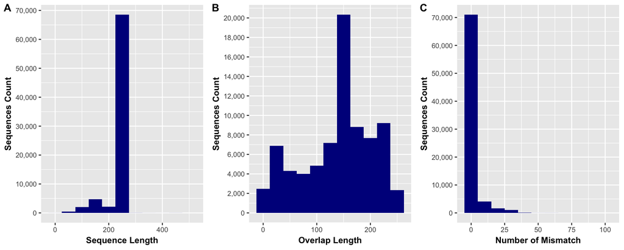

## Descriptive statistics of aligned sequence

|  | QueryLength | AlignmentLength | PercentIdentity |
| --- | --- | --- | --- |
|  | Min. :100 | Min. : 2.0 | Min. : 60.00 |
|  | 1st Qu.:252 | 1st Qu.:252.0 | 1st Qu.: 90.87 |
|  | Median :253 | Median :253.0 | Median : 93.25 |
|  | Mean :249 | Mean :249.1 | Mean : 93.29 |
|  | 3rd Qu.:253 | 3rd Qu.:253.0 | 3rd Qu.: 98.41 |
|  | Max. :298 | Max. :300.0 | Max. :100.00 |

## Features of aligned sequences

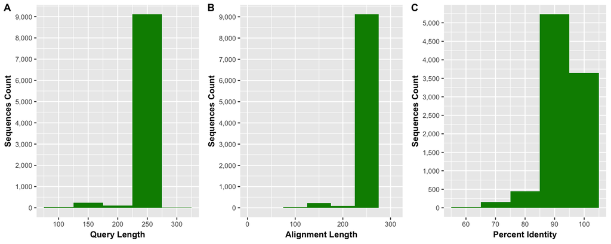

## Publication-ready figure

> Subplots of assembled (blue) and aligned (green) sequences are grouped together

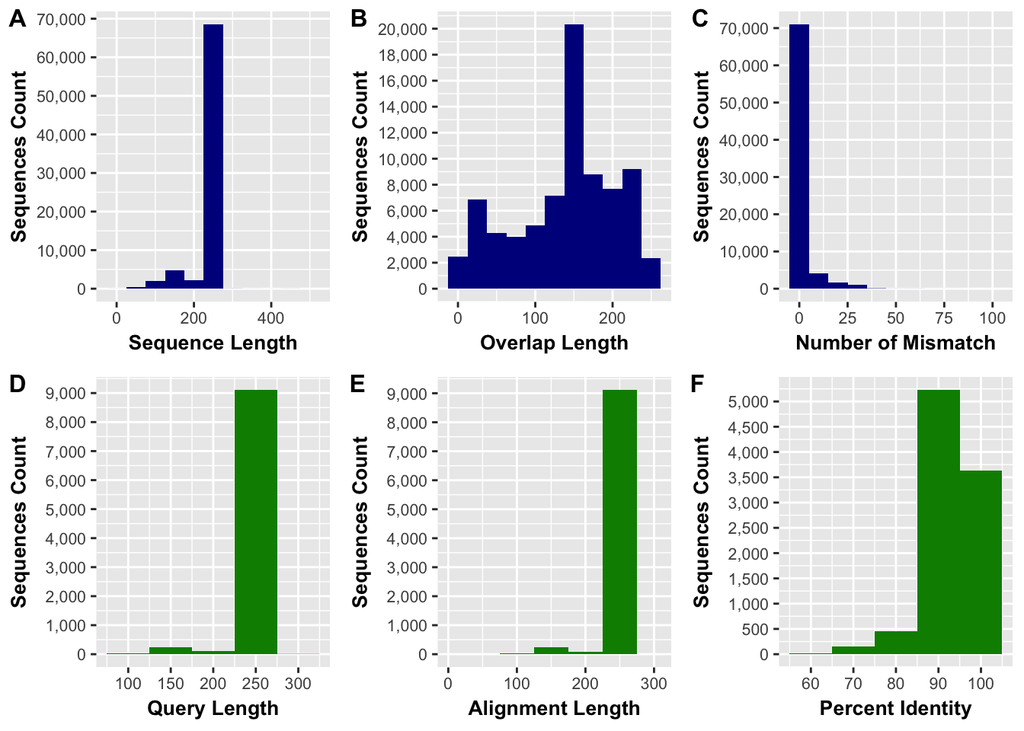

## View the first 10 rows of prosecced data

| SampleID | Original | Screened | Aligned | Denoised | NonChimeric | BacteriaOnly | NoMock |
| --- | --- | --- | --- | --- | --- | --- | --- |
| F3D001 | 5862 | 5026 | 5009 | 5009 | 4708 | 4701 | 4701 |
| F3D006 | 7985 | 7048 | 7014 | 7014 | 6603 | 6583 | 6583 |
| F3D142 | 3179 | 2788 | 2774 | 2774 | 2542 | 2537 | 2537 |
| F3D143 | 3175 | 2777 | 2764 | 2764 | 2497 | 2497 | 2497 |
| M1D001 | 6637 | 5834 | 5810 | 5810 | 5586 | 5583 | 5583 |
| M1D006 | 14403 | 12714 | 12650 | 12650 | 12326 | 12319 | 12319 |
| M1D142 | 8804 | 7613 | 7569 | 7569 | 7321 | 7321 | 7321 |
| M1D143 | 10677 | 9272 | 9221 | 9221 | 8650 | 8650 | 8650 |

## Summary statistics of processed sequences

> Shows summary of the exact number of sequences remaining at each step in 4-quantiles.

```
    Original        Screened        Aligned         Denoised
 Min.   : 3175   Min.   : 2777   Min.   : 2764   Min.   : 2764
 1st Qu.: 5191   1st Qu.: 4466   1st Qu.: 4450   1st Qu.: 4450
 Median : 7311   Median : 6441   Median : 6412   Median : 6412
 Mean   : 7590   Mean   : 6634   Mean   : 6601   Mean   : 6601
 3rd Qu.: 9272   3rd Qu.: 8028   3rd Qu.: 7982   3rd Qu.: 7982
 Max.   :14403   Max.   :12714   Max.   :12650   Max.   :12650
  NonChimeric     BacteriaOnly       NoMock
 Min.   : 2497   Min.   : 2497   Min.   : 2497
 1st Qu.: 4166   1st Qu.: 4160   1st Qu.: 4160
 Median : 6094   Median : 6083   Median : 6083
 Mean   : 6279   Mean   : 6274   Mean   : 6274
 3rd Qu.: 7653   3rd Qu.: 7653   3rd Qu.: 7653
 Max.   :12326   Max.   :12319   Max.   :12319
```

## View the first 10 row of sequence length data

```
# A tibble: 10 x 7
   Original Screened Aligned Denoised NonChimeric BacteriaOnly NoMock
      <dbl>    <dbl>   <dbl>    <dbl>       <dbl>        <dbl>  <dbl>
 1       NA       NA      NA       NA          NA           NA     NA
 2      151      253     253      252         252          252    252
 3      253      252     253      252         252          252    252
 4      252      252     253      252         252          252    252
 5      252      252     253      253         253          253    253
 6      253      253     252      252         252          252    252
 7      253      253     252      252         252          252    252
 8      253      252     251      252         252          252    252
 9      252      252     253      253         253          253    253
10      253      253     253      252         252          252    252
```

## Graphical distribution of processed sequences

### Stacked barplot

> Note that it for large number of samples it is difficult to plot the x-axis. In such situation it is good to split the samples (see example below)

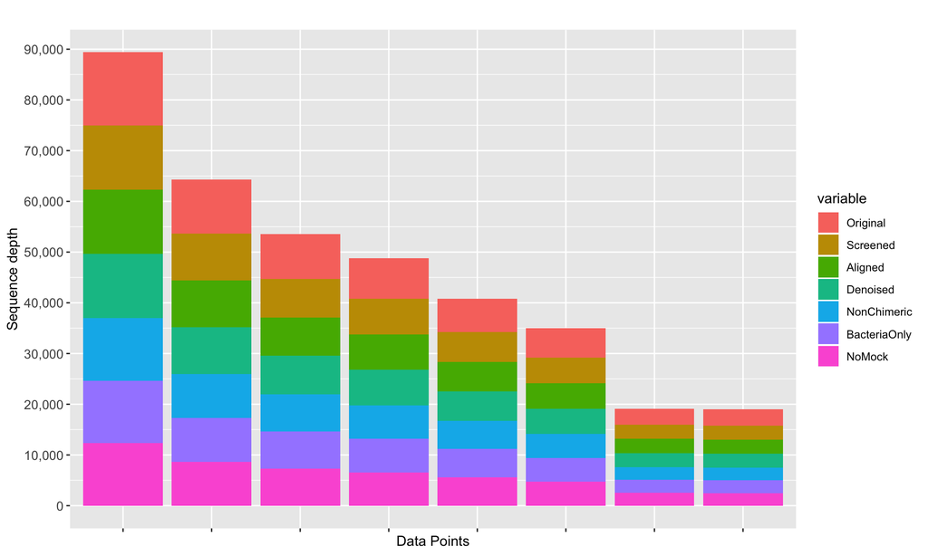

## Subsampling examples

> Below is a command for ssampling a specific dataset size. Here it shows how to filter samples with less that 2000 sequences.

### Samples with less than 2000 sequences

```r
library(dplyr)
subsetlt2000 <- seqcount.v.m %>% as.data.frame() %>% dplyr::filter(value <2000)
```

[figure not shown]

### Barplots grouped by process

> Shows maximum sequence depth.

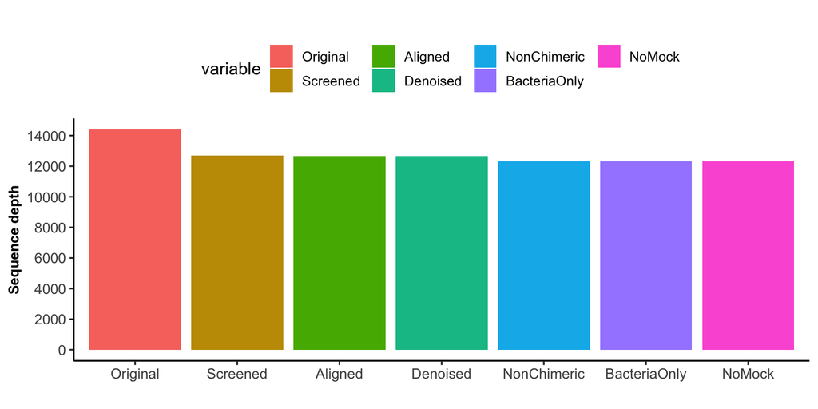

### Boxplots grouped by process

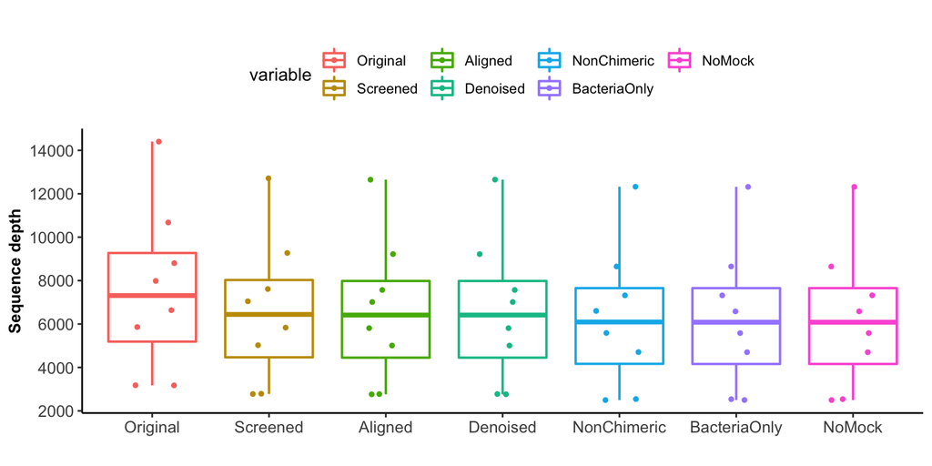

### Boxplots grouped by Var1

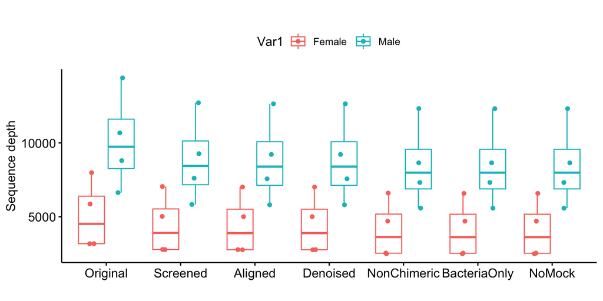

### Boxplots grouped by Var2

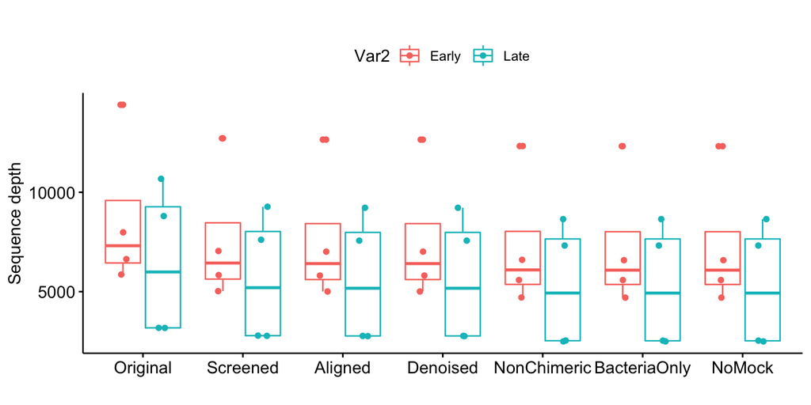

### Density plots grouped by Var1 and Var2

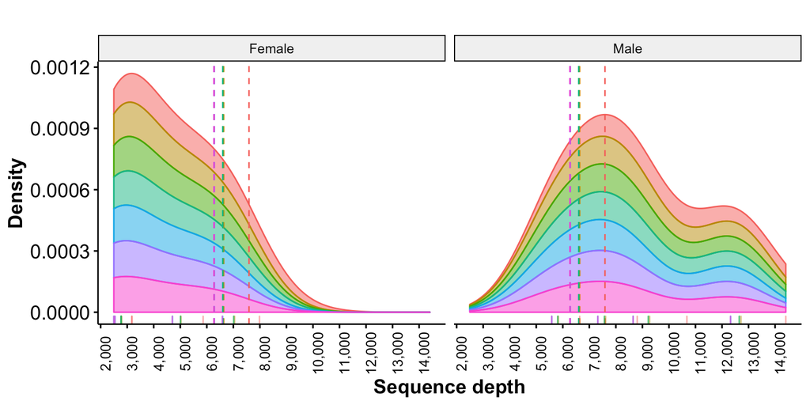

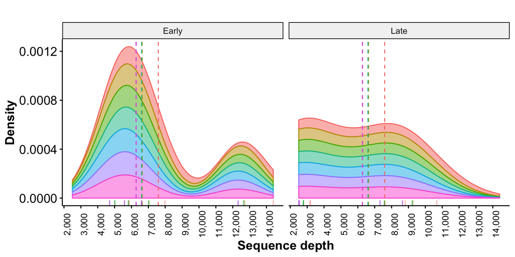

### Histograms grouped by Var1 and Var2

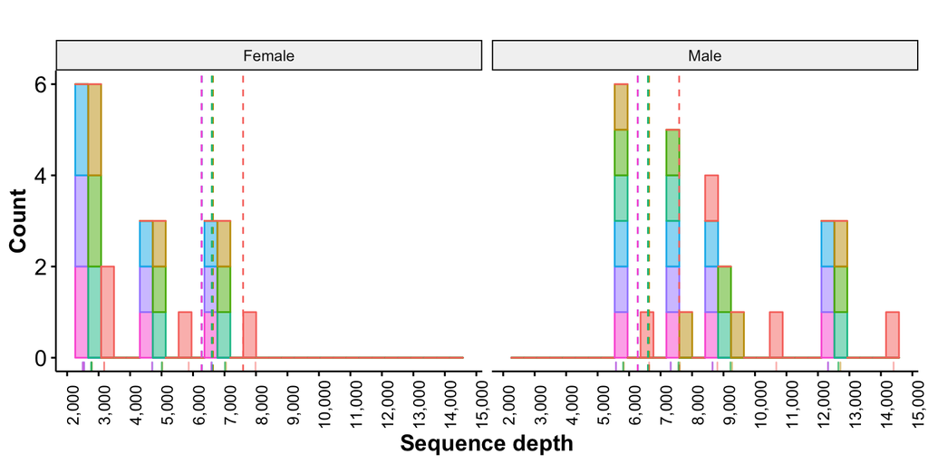

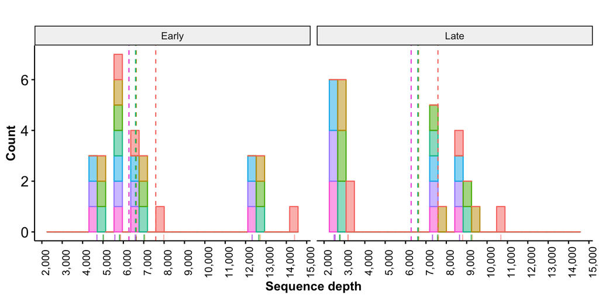

## Publication-ready figure

- All subplots on single plot:

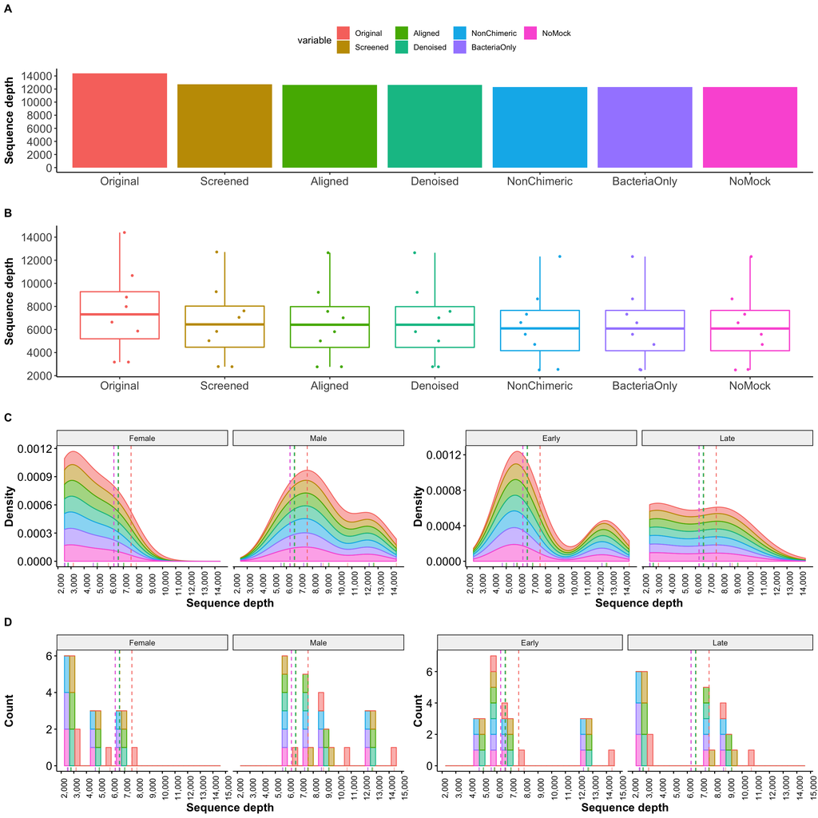

# Posible questions

### At sequence processing

- QN1: Do the paired sequences overlap as expected?
- QN2: Are there sequences to be removed from the analysis based on sequence length?
- QN3: Does the dorminant length match the targeted region of 16S rRNA gene?
- QN4: Are the representative sequences too few or too many? Note that too many non-redundant sequences may results from poor overlapping between forward and reverse reads. Review before proceeding to avoid misleading conclusions.

### At sequence classification

- QN1: What taxonomic classifier should be used? Think of need to develop and use custom classifier that suits the study objectives.
- QN2: Are there sequences assigned to non-bacterial taxonomic lineages?
- QN3: Should the matches to non-bacterial lineages be removed from further analysis?
- QN4: …….?

### At error estimation

- QN1: Is the error too high to cause rejection of the results results?
- QN2: …….?
- QN3: …….?
- QN4: …….?